# Project 4 Udacity Data Analyst Nanodegree

### Bivariate Plots

Now let’s look at various bivariate plots to see which chemical properties influence quality.

#### Quality vs Alcohol Scatterplot

How does alcohol content affect quality?

```
##    Min. 1st Qu.  Median    Mean 3rd Qu.    Max.
##    8.40    9.50   10.20   10.42   11.10   14.90
```

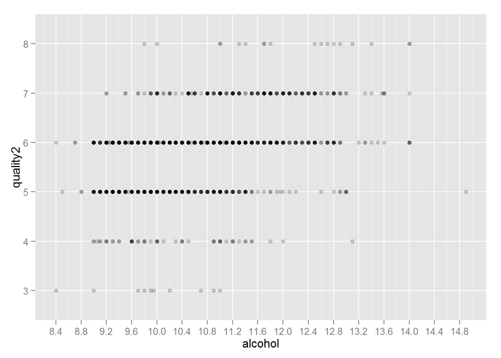

Observation: Higher quality wines tend to be associated with higher alcohol levels. Very few of the lower quality wines (3,4,5) have alcohol levels above 12, whereas more of those ranked higher (6,7,8) do.

#### Boxplot of Quality vs Alcohol

Let’s look at a boxplot to see the distribution more clearly.

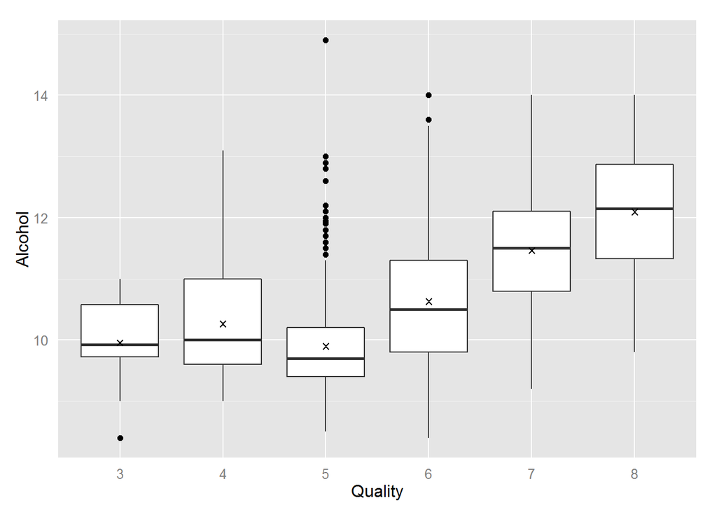

```
##
##  Pearson's product-moment correlation
##
## data:  alcohol and quality
## t = 21.639, df = 1597, p-value < 2.2e-16
## alternative hypothesis: true correlation is not equal to 0
## 95 percent confidence interval:
##  0.4373540 0.5132081
## sample estimates:
##       cor
## 0.4761663
```

Observation: Higher quality wines have higher median and mean alcohol level values. For wines with quality 5 & 6, there are outliers with high alcohol levels, but the first and third quartile values are significantly lower than wines with quality 7 & 8. Pearson’s r coefficient is 0.476.

#### Boxplot of Quality vs pH

Does pH level show a similar trend?

```
##  [1] "X"                    "fixed.acidity"        "volatile.acidity"
##  [4] "citric.acid"          "residual.sugar"       "chlorides"
##  [7] "free.sulfur.dioxide"  "total.sulfur.dioxide" "density"
## [10] "pH"                   "sulphates"            "alcohol"
## [13] "quality"              "quality2"
```

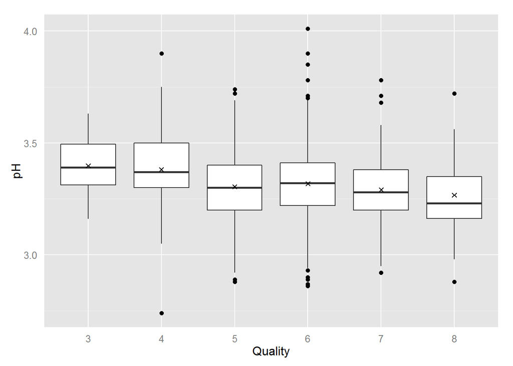

```
##
##  Pearson's product-moment correlation
##
## data:  pH and quality
## t = -2.3109, df = 1597, p-value = 0.02096
## alternative hypothesis: true correlation is not equal to 0
## 95 percent confidence interval:
##  -0.106451268 -0.008734972
## sample estimates:
##         cor
## -0.05773139
```

Observation: pH levels seem more or less consistent for wines of different quality, especially those ranked 5,6,7. Poorly ranked wines tend to have higher pH values, whereas highly ranked wines tend to have lower pH values. The difference between the first and third quartiles appears to be only about 0.2 units for each boxplot, which could mean that small changes in pH levels could be significant. I have read that pH level has a significant impact on how a wine tastes and how well it ages. Pearson’s r coefficient is -0.0577.

#### More Boxplots of Quality vs Chemicals

Let’s look at boxplots for the remaining variables.

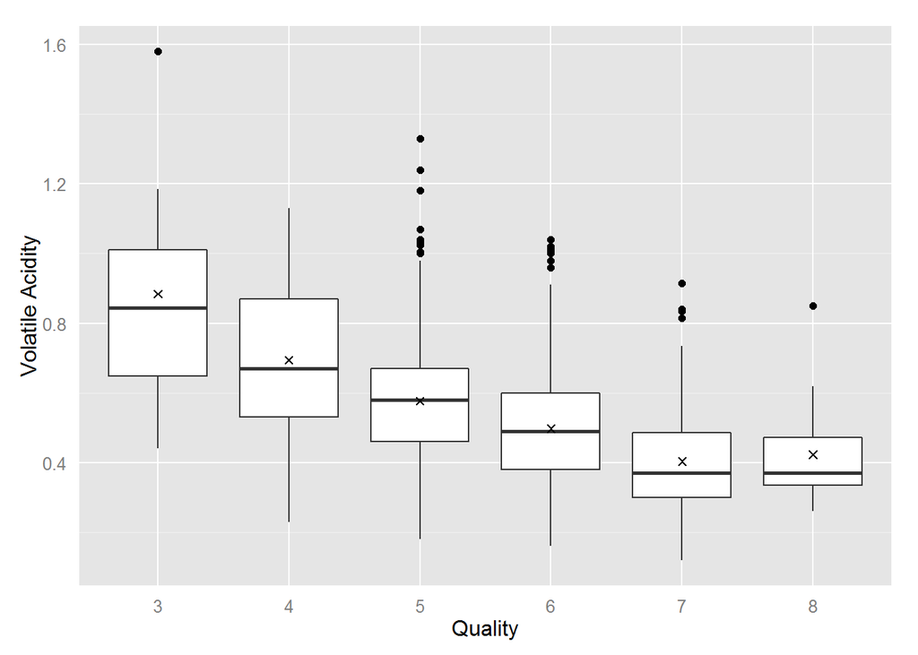

```
##
##  Pearson's product-moment correlation
##
## data:  volatile.acidity and quality
## t = -16.954, df = 1597, p-value < 2.2e-16
## alternative hypothesis: true correlation is not equal to 0
## 95 percent confidence interval:
##  -0.4313210 -0.3482032
## sample estimates:
##        cor
## -0.3905578
```

Observation: For wines with higher quality, volatile acidity tends to be significantly lower. Pearson’s r coefficient is -0.391.

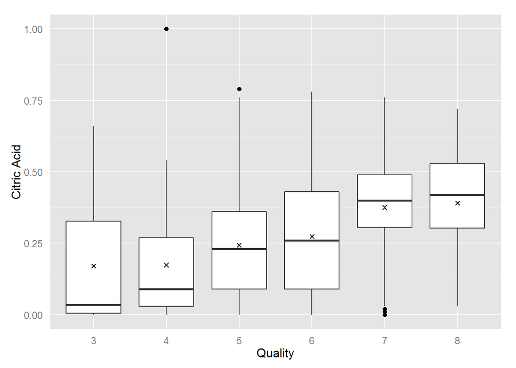

```
##
##  Pearson's product-moment correlation
##
## data:  citric.acid and quality
## t = 9.2875, df = 1597, p-value < 2.2e-16
## alternative hypothesis: true correlation is not equal to 0
## 95 percent confidence interval:
##  0.1793415 0.2723711
## sample estimates:
##       cor
## 0.2263725
```

Observation: For wines with higher quality, citric acid levels tend to be significantly higher. Pearson’s r coefficient is 0.226.

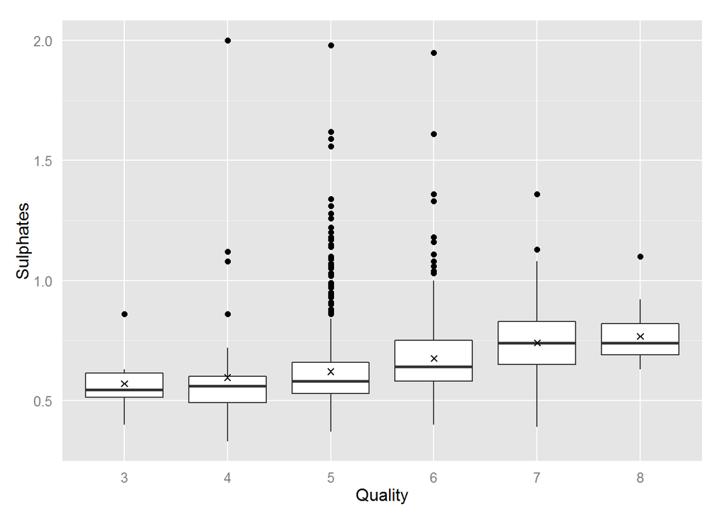

```
##
##  Pearson's product-moment correlation
##
## data:  sulphates and quality
## t = 10.38, df = 1597, p-value < 2.2e-16
## alternative hypothesis: true correlation is not equal to 0
## 95 percent confidence interval:
##  0.2049011 0.2967610
## sample estimates:
##       cor
## 0.2513971
```

Observation: Sulphate levels tend to be higher for higher quality wines. Pearson’s r coefficient is 0.251.

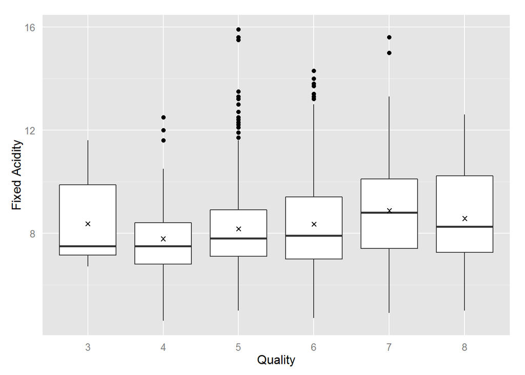

```
##
##  Pearson's product-moment correlation
##
## data:  fixed.acidity and quality
## t = 4.996, df = 1597, p-value = 6.496e-07
## alternative hypothesis: true correlation is not equal to 0
## 95 percent confidence interval:
##  0.07548957 0.17202667
## sample estimates:
##       cor
## 0.1240516
```

Observation: Fixed acidity doesn’t appear to be strongly correlated with wine quality. Pearson’s r coefficient is 0.124.

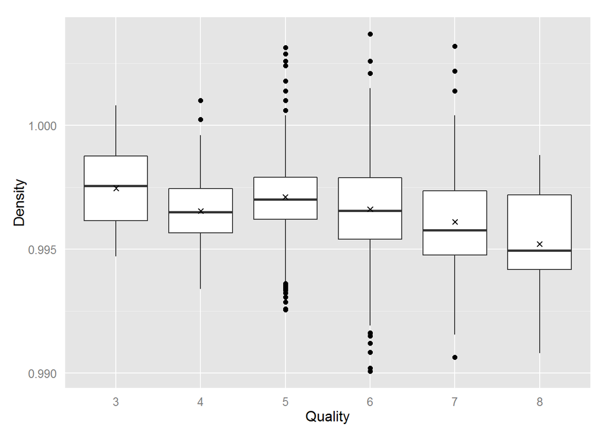

```
##
##  Pearson's product-moment correlation
##
## data:  density and quality
## t = -7.0997, df = 1597, p-value = 1.875e-12
## alternative hypothesis: true correlation is not equal to 0
## 95 percent confidence interval:
##  -0.2220365 -0.1269870
## sample estimates:
##        cor
## -0.1749192
```

Observation: Density appears to drop slightly for higher quality wines. Pearson’s r coefficient is -0.175.

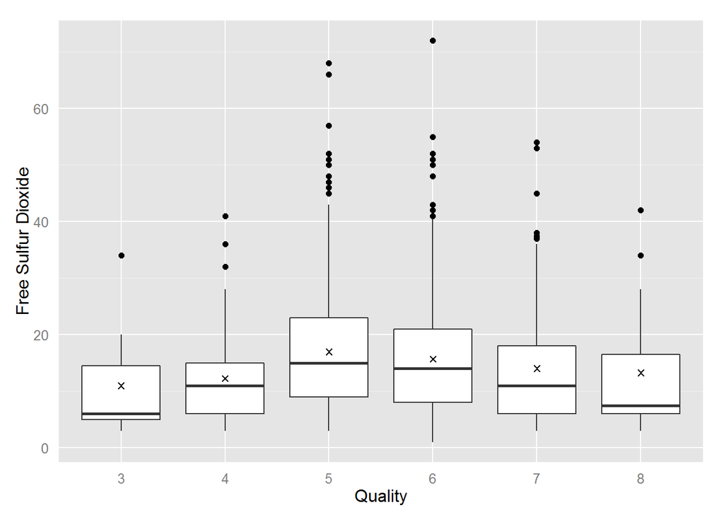

```
##
##  Pearson's product-moment correlation
##
## data:  free.sulfur.dioxide and quality
## t = -2.0269, df = 1597, p-value = 0.04283
## alternative hypothesis: true correlation is not equal to 0
## 95 percent confidence interval:
##  -0.099430290 -0.001638987
## sample estimates:
##         cor
## -0.05065606
```

Observation: Free sulfur dioxide doesn’t appear to be strongly correlated with wine quality. Pearson’s r coefficient is -0.051.

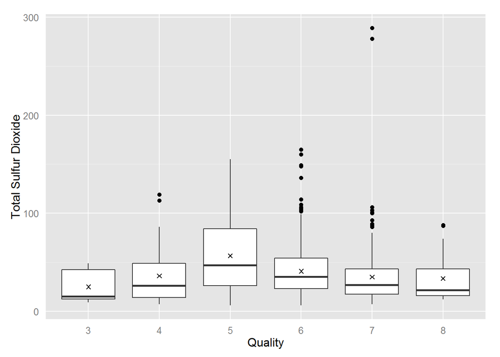

```
##
##  Pearson's product-moment correlation
##
## data:  total.sulfur.dioxide and quality
## t = -7.5271, df = 1597, p-value = 8.622e-14
## alternative hypothesis: true correlation is not equal to 0
## 95 percent confidence interval:
##  -0.2320162 -0.1373252
## sample estimates:
##        cor
## -0.1851003
```

Observation: Total sulfur dioxide tends to decrease as quality increases, at least for wines rated between 5 and 8 for quality. Pearson’s r coefficient is -0.185.

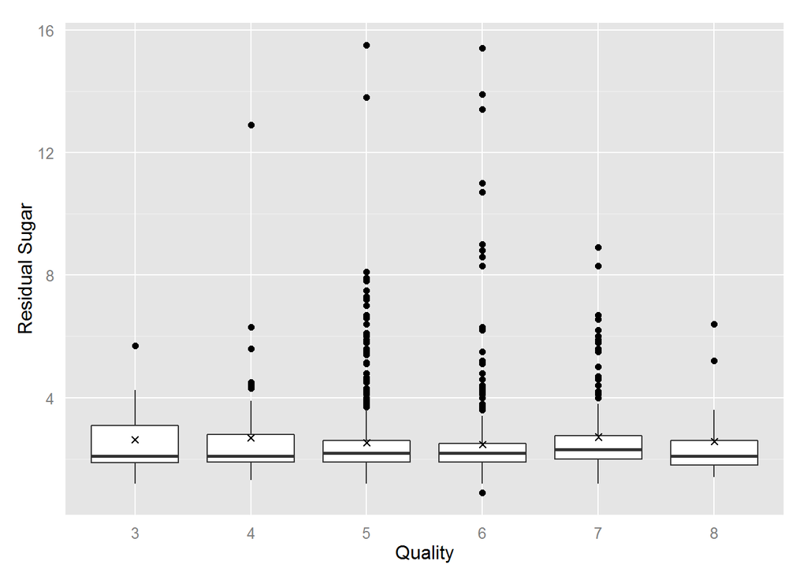

```
##
##  Pearson's product-moment correlation
##
## data:  residual.sugar and quality
## t = 0.5488, df = 1597, p-value = 0.5832
## alternative hypothesis: true correlation is not equal to 0
## 95 percent confidence interval:
##  -0.03531327  0.06271056
## sample estimates:
##        cor
## 0.01373164
```

Observation: There does not appear to be a significant correlation between residual sugar and wine quality. Pearson’s r coefficient is 0.0137.

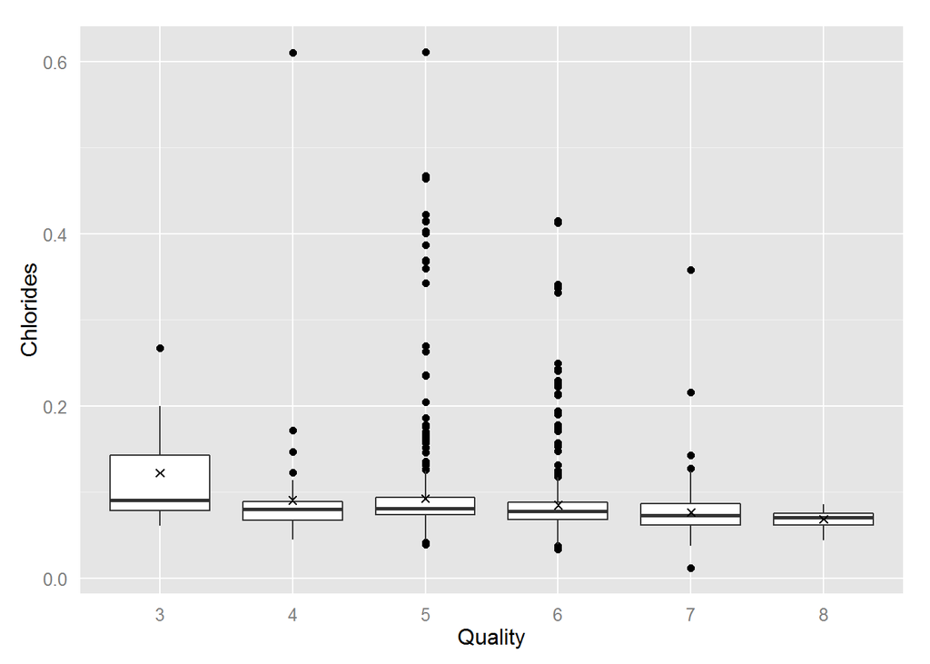

```
##
##  Pearson's product-moment correlation
##
## data:  chlorides and quality
## t = -5.1948, df = 1597, p-value = 2.313e-07
## alternative hypothesis: true correlation is not equal to 0
## 95 percent confidence interval:
##  -0.17681041 -0.08039344
## sample estimates:
##        cor
## -0.1289066
```

Observation: Chloride levels tend to be lower for higher quality wines. The comparatively small range between first and third quartile values for chloride levels suggests that small increases or decreases in chloride levels may be significant. Pearson’s r coefficient is -0.129.

The chemicals with the highest Pearson’s r coefficient are alcohol level (r = 0.476), volatile acidity (r = -0.39), citric acid (r = 0.226) and sulphates (r = 0.251).

#### Numerical Correlation of Quality vs Alcohol

Summary data from the boxplots can be displayed numerically as well, showing distribution of various chemicals for each quality score. Here is an example for alcohol level.

```
## wines$quality2: 3
##    Min. 1st Qu.  Median    Mean 3rd Qu.    Max.
##   8.400   9.725   9.925   9.955  10.580  11.000
## --------------------------------------------------------
## wines$quality2: 4
##    Min. 1st Qu.  Median    Mean 3rd Qu.    Max.
##    9.00    9.60   10.00   10.27   11.00   13.10
## --------------------------------------------------------
## wines$quality2: 5
##    Min. 1st Qu.  Median    Mean 3rd Qu.    Max.
##     8.5     9.4     9.7     9.9    10.2    14.9
## --------------------------------------------------------
## wines$quality2: 6
##    Min. 1st Qu.  Median    Mean 3rd Qu.    Max.
##    8.40    9.80   10.50   10.63   11.30   14.00
## --------------------------------------------------------
## wines$quality2: 7
##    Min. 1st Qu.  Median    Mean 3rd Qu.    Max.
##    9.20   10.80   11.50   11.47   12.10   14.00
## --------------------------------------------------------
## wines$quality2: 8
##    Min. 1st Qu.  Median    Mean 3rd Qu.    Max.
##    9.80   11.32   12.15   12.09   12.88   14.00
```

Observation: This summary data reflects the visual representation showing that as alcohol levels increase, the quartile, mean and median values tend to increase as well, especially for the higher quality wines ranked 7 and 8.

#### Conditional Means of Chemical Values by Quality Level

Let’s look at the mean values of each of the chemicals for each quality level as another way to explore correlations.

```
##  [1] "X"                    "fixed.acidity"        "volatile.acidity"
##  [4] "citric.acid"          "residual.sugar"       "chlorides"
##  [7] "free.sulfur.dioxide"  "total.sulfur.dioxide" "density"
## [10] "pH"                   "sulphates"            "alcohol"
## [13] "quality"              "quality2"
```

```
## Source: local data frame [6 x 13]
##
##   quality alcohol_mean  pH_mean vol_acid_mean citric_acid_mean
##     (int)        (dbl)    (dbl)         (dbl)            (dbl)
## 1       3     9.955000 3.398000     0.8845000        0.1710000
## 2       4    10.265094 3.381509     0.6939623        0.1741509
## 3       5     9.899706 3.304949     0.5770411        0.2436858
## 4       6    10.629519 3.318072     0.4974843        0.2738245
## 5       7    11.465913 3.290754     0.4039196        0.3751759
## 6       8    12.094444 3.267222     0.4233333        0.3911111
## Variables not shown: sulphate_mean (dbl), fixed_acid_mean (dbl),
##   density_mean (dbl), sugar_mean (dbl), chlorides_mean (dbl), freeSO2_mean
##   (dbl), totalSO2_mean (dbl), n (int)
```

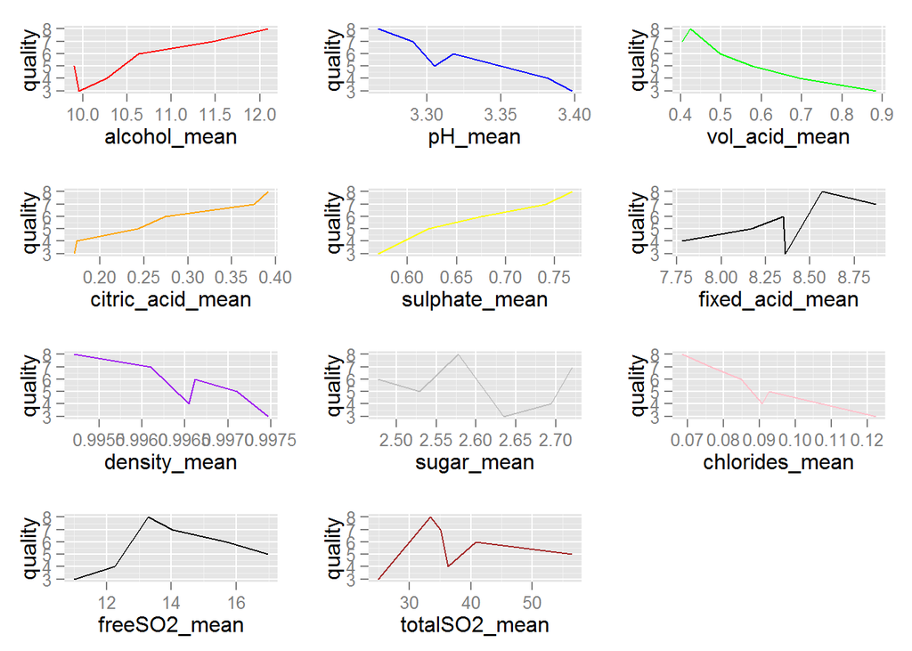

Observation: These line graphs confirm our earlier findings, namely that quality rises as alcohol levels increase, pH level decreases, volatile acididity decreases, citric acid increases, sulphates increase, density decreases, and chlorides decrease.

#### Histograms of Chemicals

Let’s look at histograms of each chemical by quality level to see if we can glean any other insights.

##### Histograms of Alcohol Levels by Quality

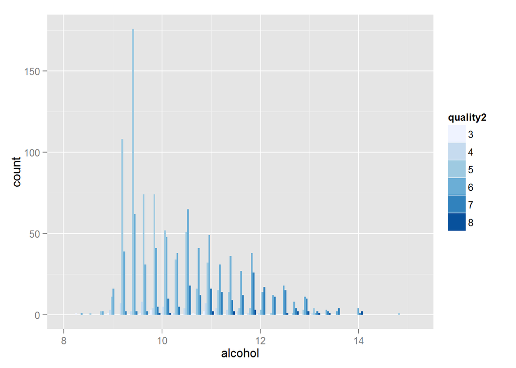

Observation: The coloring shows that higher alcohol levels have a higher percentage of wines ranked as 6,7 or 8. Almost no wines below alcohol level 10 have a quality ranking of 7 or 8.

##### Histogram of Volatile Acidity

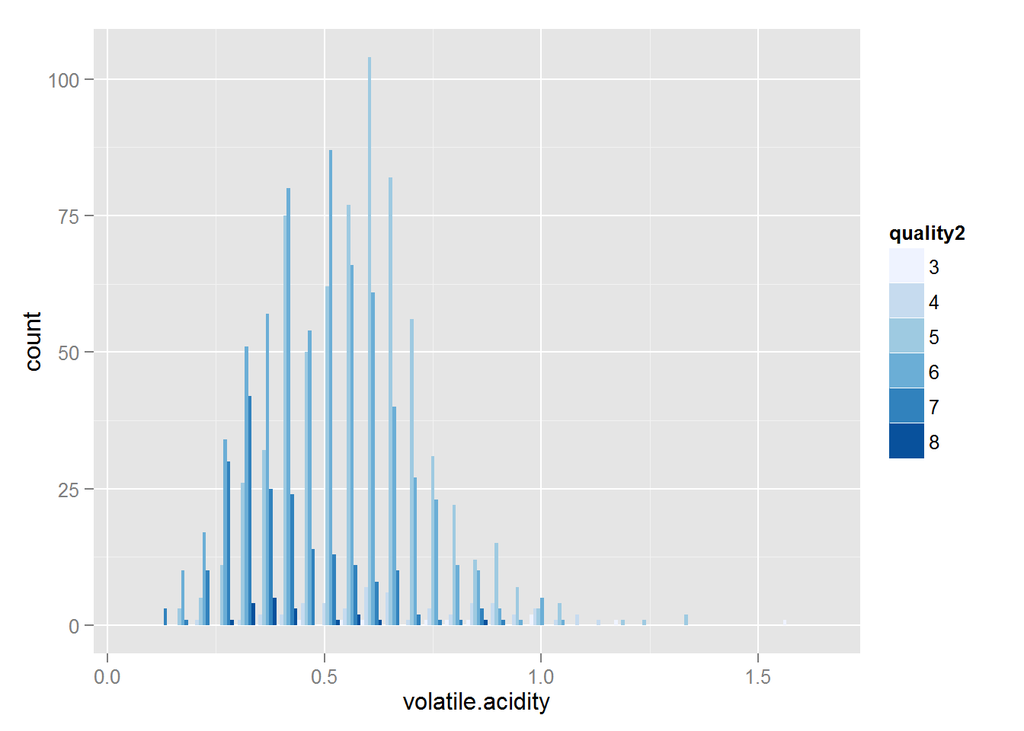

Observation: Lower values of volatile acidity clearly have a greater proportion of higher quality values. There are almost no wines rated 7 or 8 for volatile acidity above 0.7.

##### Histogram of Citric Acid

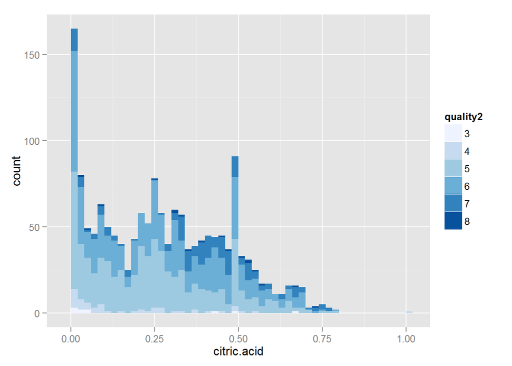

Observation: Citric acid values of 0.3 or greater tend to have a higher proportion of wines rated 6-8 for quality. There were also a relatively large number of wines rated 6 or 7 that contained no citric acid.

##### Histogram of pH

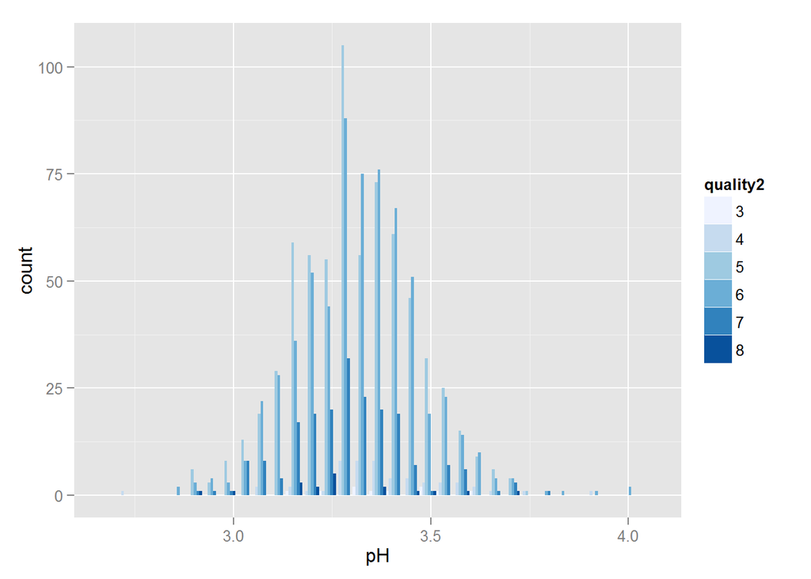

Observation: The pH distribution is relatively normal, with values below the mean having a higher proportion of wines rated at a 7 or 8.

##### Histogram of Sulphates

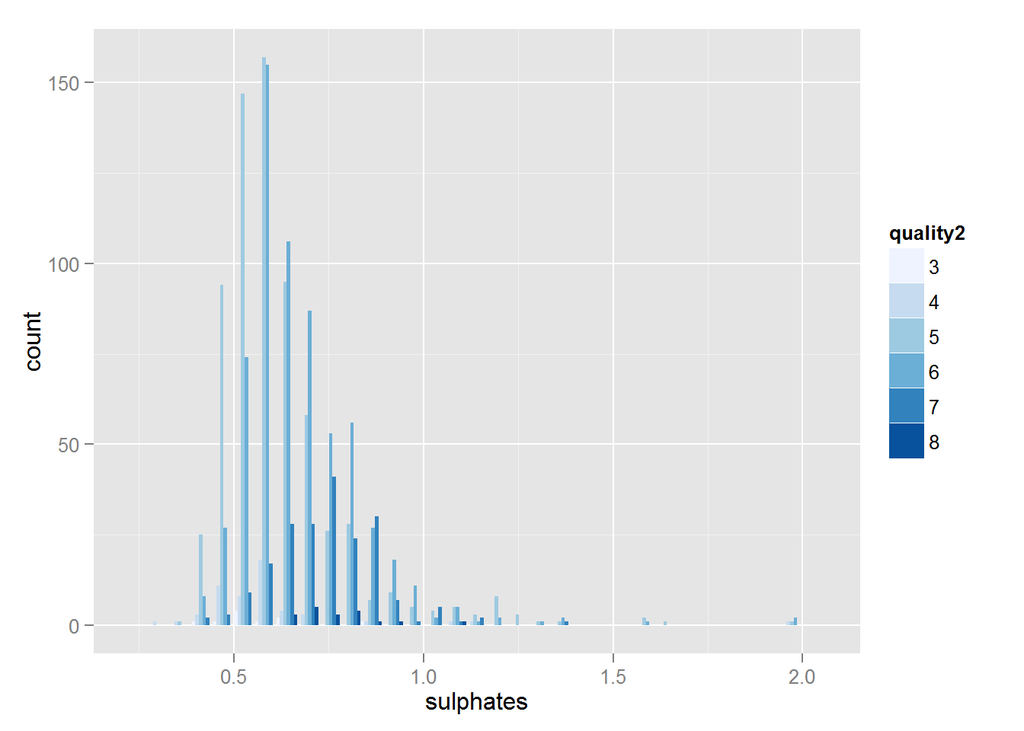

Observation: Higher sulphate values correspond to a higher proportion of quality 7,8 wines.

##### Histogram of Chlorides

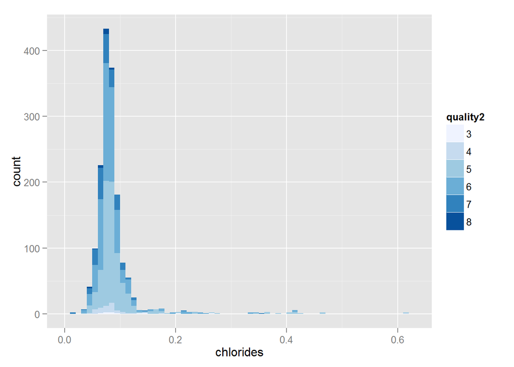

Observation: Chloride values below the mean have a higher proportion and number of wines rated 6,7 and 8 for quality.

##### Histogram of Density

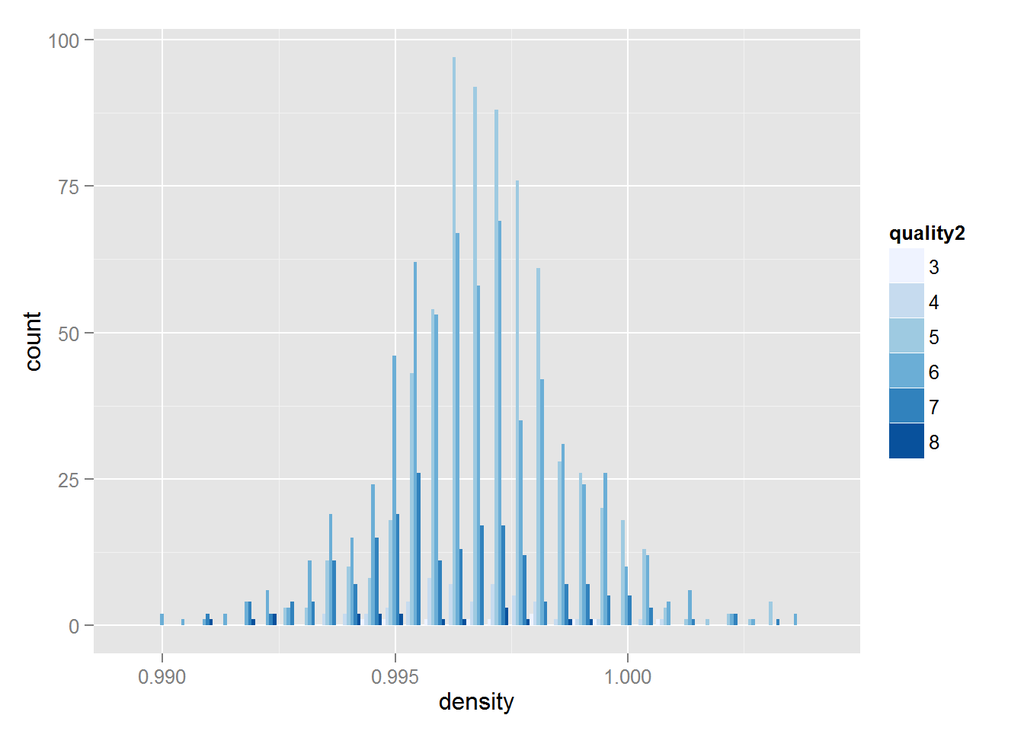

Observation: Density values below the mean have a slightly higher proportion of wines rated 7 for quality.

##### Histogram of Total Sulfur Dioxide

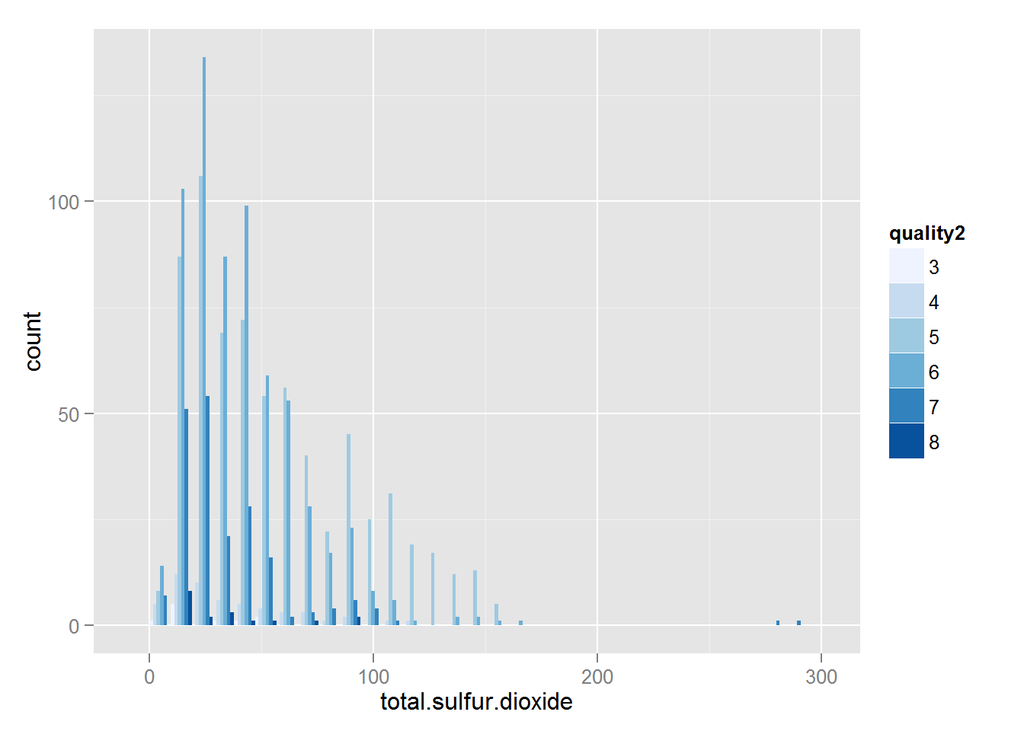

Observation: Lower sulfur dioxide values tend to have a higher proportion of wines rated 6,7 and 8 for quality.

#### Bivariate Pairs Summary

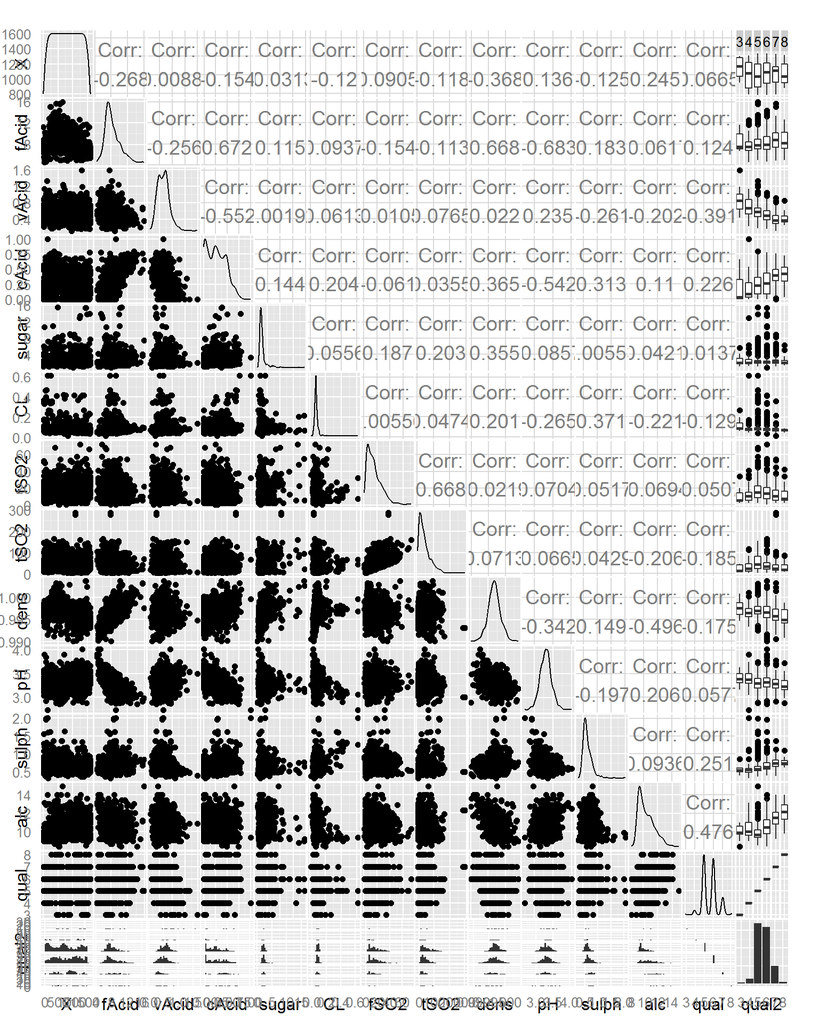

### Multivariate Plots

We now focus on how multiple chemical values influence quality level.

#### Alcohol, Volatile Acidity and Quality

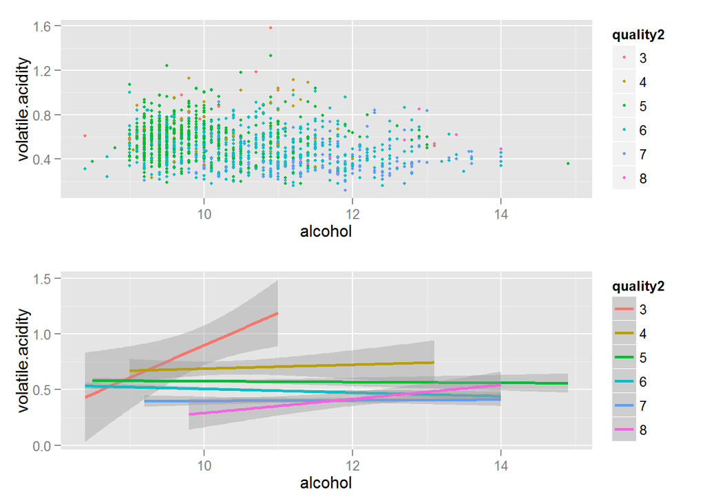

Observation: Clearly, wines with lower volatile acidity and higher alcohol levels tend to be ranked higher, as most wines ranked 7 and 8 are in the lower right hand section.

#### Density, pH and Quality

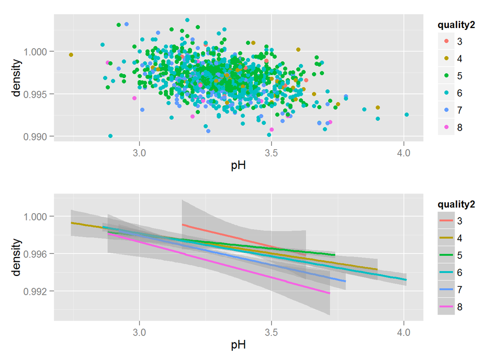

Observation: Wines with lower density tend to have higher quality, as do lines with lower pH values.

#### Sulphates, Citric Acid and Quality

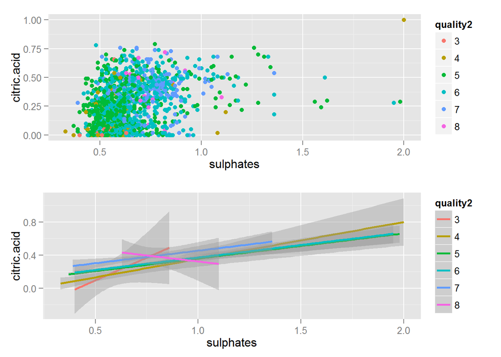

Observation: Wines with higher sulphates and higher citric acid levels tend to have higher quality.

#### Alcohol, Volatile Acidity, Citric Acid & Quality

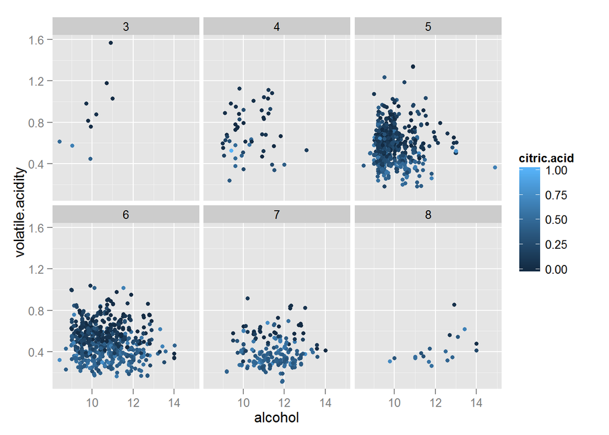

Observation: Wines with quality rating 7 or 8 tend to have higher alcohol levels, lower volatile acidity and higher citric acid levels.

#### Sulphates, Density, pH & Quality

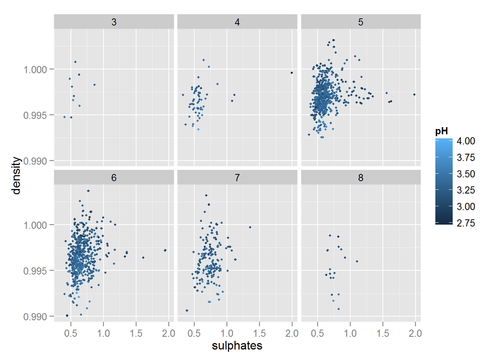

Observation: Wines with quality rating 7 or 8 tend to have higher sulphate values, lower density values and lower pH values.

#### Alcohol, pH, Chlorides & Quality

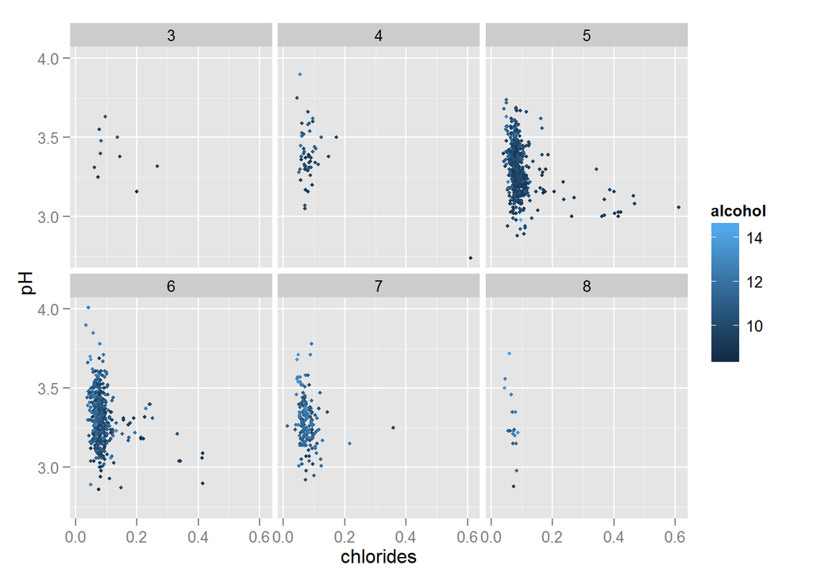

Observation: The spread of chloride values is smaller for wines with 7 or 8 quality, hovering around 0.1. The pH level drops as well, and alcohol levels are higher for higher quality wines.

## Final Plots & Summary

### Plot 1: Influence of Alcohol Level on Quality

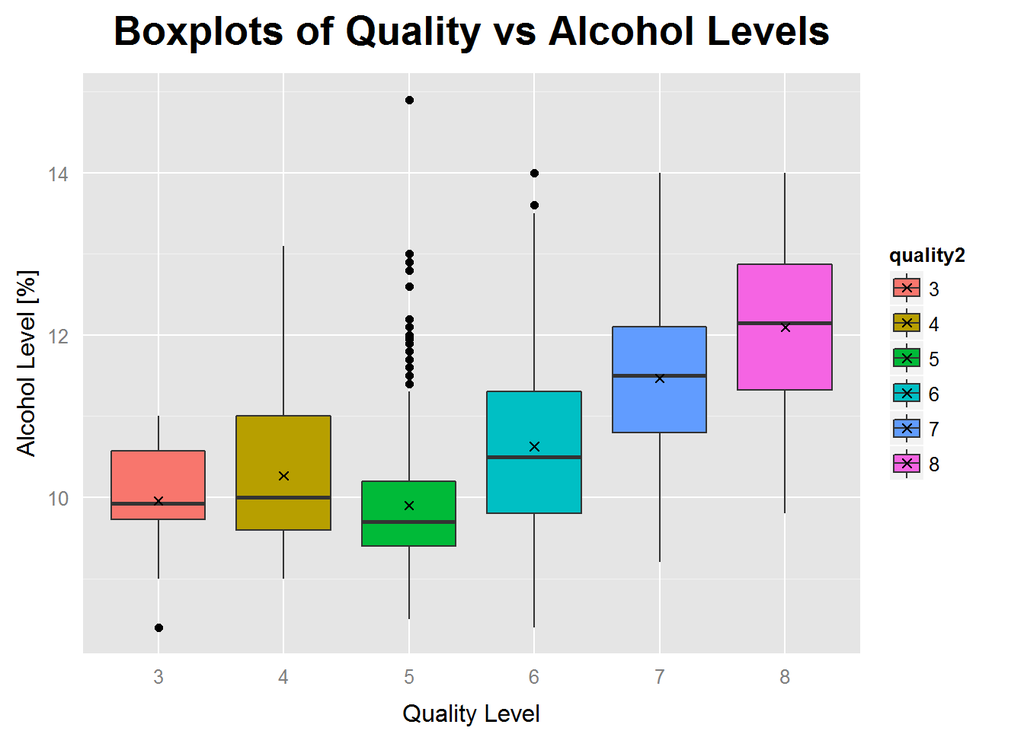

```
## wines$quality2: 3
##    Min. 1st Qu.  Median    Mean 3rd Qu.    Max.
##   8.400   9.725   9.925   9.955  10.580  11.000
## --------------------------------------------------------
## wines$quality2: 4
##    Min. 1st Qu.  Median    Mean 3rd Qu.    Max.
##    9.00    9.60   10.00   10.27   11.00   13.10
## --------------------------------------------------------
## wines$quality2: 5
##    Min. 1st Qu.  Median    Mean 3rd Qu.    Max.
##     8.5     9.4     9.7     9.9    10.2    14.9
## --------------------------------------------------------
## wines$quality2: 6
##    Min. 1st Qu.  Median    Mean 3rd Qu.    Max.
##    8.40    9.80   10.50   10.63   11.30   14.00
## --------------------------------------------------------
## wines$quality2: 7
##    Min. 1st Qu.  Median    Mean 3rd Qu.    Max.
##    9.20   10.80   11.50   11.47   12.10   14.00
## --------------------------------------------------------
## wines$quality2: 8
##    Min. 1st Qu.  Median    Mean 3rd Qu.    Max.
##    9.80   11.32   12.15   12.09   12.88   14.00
```

Commentary: Higher quality wines tend to be associated with higher alcohol levels. The first quartile, median, mean and third quartile values increase steadily for wines with quality levels 5-8. First quartile increases from 9.4 to 11.32, median from 9.7 to 12.15, and third quartile from 10.2 to 12.88 between levels 5 and 8. Pearson’s r correlation coefficient for alcohol is 0.476, closer to 1 than any other chemical in relation to quality.

### Plot 2: Plots Showing Spread of Chemical Values by Quality

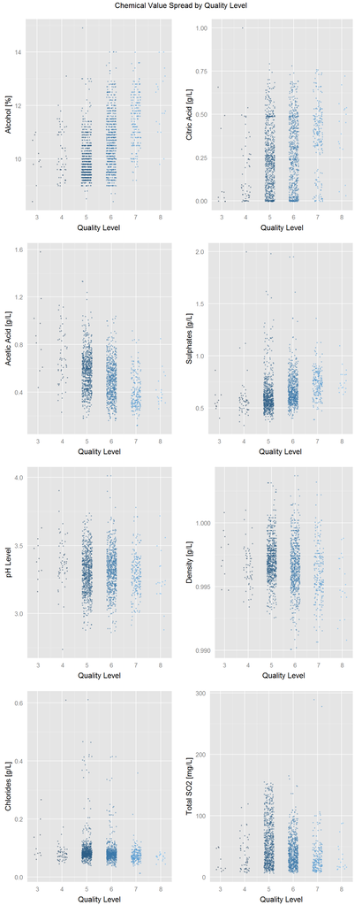